# Step 3 — Preprocessing

Jackson & Fischer et al. (2020) Breast Cancer | imcdatasets

Author

mass-cytometry-explorations

Published

September 5, 2026

## 1 Overview

This notebook performs **Step 3** of the replication workflow: preprocessing the QC-filtered single-cell object for downstream dimensionality reduction and clustering.

Inputs from Step 2:

- `results/sce_qc_filtered.rds`

Outputs from this notebook:

- `results/preprocessing_summary/marker_preprocessing_metrics.csv`
- `results/preprocessing_summary/preprocessing_parameters.csv`
- `results/sce_preprocessed.rds`

## 2 Setup

```r
suppressPackageStartupMessages({
  library(SingleCellExperiment)
  library(ggplot2)
  library(dplyr)
  library(patchwork)
})

# Resolve project/notebook paths robustly, without absolute paths.
if (basename(getwd()) == "notebooks") { # Check if running from notebooks/ directory.
  notebooks_dir <- normalizePath(getwd())
} else if (dir.exists(file.path(getwd(), "notebooks"))) { # Check if running from project root.
  notebooks_dir <- normalizePath(file.path(getwd(), "notebooks"))
} else { # If neither then stop with an error message.
  stop("Run from project root or notebooks/ directory.")
}

if (!identical(normalizePath(getwd()), notebooks_dir)) { # Set working directory to notebooks/ if not already there.
  setwd(notebooks_dir)
}

cat("Working directory:", getwd(), "\n") # Tell the user where the notebook is running from.
```

```
Working directory: /home/lizalfos/mass-cytometry-explorations/notebooks
```

```r
dir.create(file.path("..", "results", "preprocessing_summary"),
           recursive = TRUE, showWarnings = FALSE)
dir.create(file.path("..", "figures", "03_preprocessing"),
           recursive = TRUE, showWarnings = FALSE)
```

## 3 Load QC-filtered data

```r
sce_path <- file.path("..", "results", "sce_qc_filtered.rds")
if (!file.exists(sce_path)) {
  stop("Missing results/sce_qc_filtered.rds. Please render notebooks/02_quality_control.qmd first.")
}

sce_qc <- readRDS(sce_path)
sce_qc
```

```
class: SingleCellExperiment
dim: 45 272975
metadata(0):
assays(3): counts exprs quant_norm
rownames(45): Ru96 Ru98 ... DNA1 DNA2
rowData names(6): metal name ... channel antibody_clone
colnames(272975): 1_1 1_2 ... 375_3940 375_3942
colData names(74): image_name cell_id ... patient_cohort cell_number
reducedDimNames(0):
mainExpName: JacksonFischer_2020_BreastCancer_Basel_v2
altExpNames(0):
```

## 4 Select analysis assay

The preferred assay order for downstream analysis is:

1. `exprs` (asinh-transformed)
2. `quant_norm` (quantile-normalised)
3. `counts` (raw)

asinh-transformed is similar to log-transformed data, but asinh is used for cytometry. This is because it handles zero and negative values gracefully, which are common in cytometry data due to background interference, while scRNA-seq data has no negative values. Log1p cannot process negative data.

Further reading on the topic can be found in the following references: [Direct comparison of mass cytometry and single-cell RNA sequencing of human peripheral blood mononuclear cells](https://pmc.ncbi.nlm.nih.gov/articles/PMC11139855/)

[Comparison of transformations for single-cell RNA-seq data](https://doi.org/10.1038/s41592-023-01814-1)

```r
available_assays <- assayNames(sce_qc)
preferred_assays <- c("exprs", "quant_norm", "counts")
analysis_assay <- preferred_assays[preferred_assays %in% available_assays][1]

if (is.na(analysis_assay)) {
  stop("No supported assay found. Expected one of: exprs, quant_norm, counts.")
}

analysis_mat <- assay(sce_qc, analysis_assay)
cat("Selected assay:", analysis_assay, "\n")
```

```
Selected assay: exprs
```

## 5 Marker preprocessing metrics

Here we set minimum percentage of cells that the marker is nonzero in (1% cutoff). Then checks which markers meet this criterion and have non-zero variance, retaining only those for downstream analysis. It also makes sure the data is a valid finite number(not NA).

```r
min_pct_nonzero <- 1
n_top_variable_markers <- 30L

marker_metrics <- data.frame(
  marker_name = rownames(sce_qc),
  mean_expr = rowMeans(analysis_mat, na.rm = TRUE),
  median_expr = apply(analysis_mat, 1, median, na.rm = TRUE),
  variance_expr = apply(analysis_mat, 1, var, na.rm = TRUE),
  pct_cells_nonzero = rowMeans(analysis_mat > 0, na.rm = TRUE) * 100
) |>
  dplyr::mutate(
    keep_marker = pct_cells_nonzero >= min_pct_nonzero & is.finite(variance_expr) & variance_expr > 0
  ) |>
  dplyr::arrange(dplyr::desc(variance_expr))

n_keep <- sum(marker_metrics$keep_marker)
cat(sprintf("Markers before preprocessing: %d\n", nrow(marker_metrics)))
```

```
Markers before preprocessing: 45
```

```r
cat(sprintf("Markers retained: %d\n", n_keep))
```

```
Markers retained: 42
```

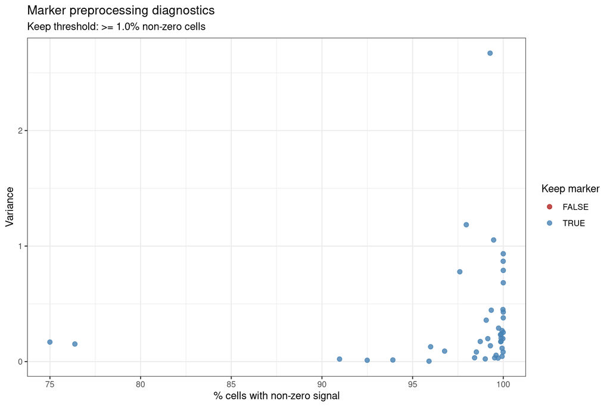

Figure 1: Marker variance versus prevalence (% cells with non-zero signal). Red points fail marker preprocessing.

```r
base_plot <- ggplot(marker_metrics,
       aes(x = pct_cells_nonzero, y = variance_expr, colour = keep_marker)) +
  geom_point(alpha = 0.8, size = 2) +
  scale_colour_manual(values = c("TRUE" = "steelblue", "FALSE" = "firebrick")) +
  labs(
    title = "Marker preprocessing diagnostics",
    subtitle = sprintf("Keep threshold: >= %.1f%% non-zero cells", min_pct_nonzero),
    x = "% cells with non-zero signal",
    y = "Variance",
    colour = "Keep marker"
  ) +
  theme_bw()
base_plot
```

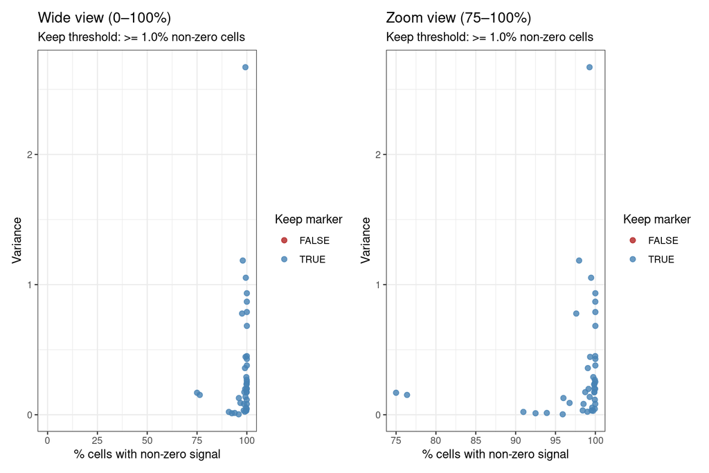

```r
p_wide <- base_plot +
  coord_cartesian(xlim = c(0, 100)) +
  ggtitle("Wide view (0–100%)")

# Zoomed view: focus on lower x range (example: 0–25%)
p_zoom <- base_plot +
  coord_cartesian(xlim = c(75, 100)) +
  ggtitle("Zoom view (75–100%)")

p_wide + p_zoom
```

## 6 Build preprocessed object

```r
keep_markers <- marker_metrics$marker_name[marker_metrics$keep_marker]
sce_preprocessed <- sce_qc[keep_markers, ]

# Recompute matrix after marker filtering.
analysis_mat_keep <- assay(sce_preprocessed, analysis_assay)

# Add scaled assay for downstream methods that assume marker-wise centering/scaling.
scaled_mat <- t(scale(t(analysis_mat_keep)))
scaled_mat[!is.finite(scaled_mat)] <- 0
assay(sce_preprocessed, "scaled") <- scaled_mat

# Flag top variable markers (for DR/clustering feature selection).
marker_metrics_keep <- marker_metrics |>
  dplyr::filter(keep_marker)

top_n <- min(n_top_variable_markers, nrow(marker_metrics_keep))
top_markers <- marker_metrics_keep$marker_name[seq_len(top_n)]

rowData(sce_preprocessed)$marker_variance <- marker_metrics_keep$variance_expr[
  match(rownames(sce_preprocessed), marker_metrics_keep$marker_name)
]
rowData(sce_preprocessed)$pct_cells_nonzero <- marker_metrics_keep$pct_cells_nonzero[
  match(rownames(sce_preprocessed), marker_metrics_keep$marker_name)
]
rowData(sce_preprocessed)$use_for_dr <- rownames(sce_preprocessed) %in% top_markers

metadata(sce_preprocessed)$preprocessing <- list(
  analysis_assay = analysis_assay,
  min_pct_nonzero = min_pct_nonzero,
  n_top_variable_markers = n_top_variable_markers,
  n_markers_retained = nrow(sce_preprocessed),
  n_cells_retained = ncol(sce_preprocessed)
)

cat(sprintf("Cells retained: %d\n", ncol(sce_preprocessed)))
```

```
Cells retained: 272975
```

```r
cat(sprintf("Markers retained: %d\n", nrow(sce_preprocessed)))
```

```
Markers retained: 42
```

```r
cat(sprintf("Top variable markers flagged for DR: %d\n", sum(rowData(sce_preprocessed)$use_for_dr)))
```

```
Top variable markers flagged for DR: 30
```

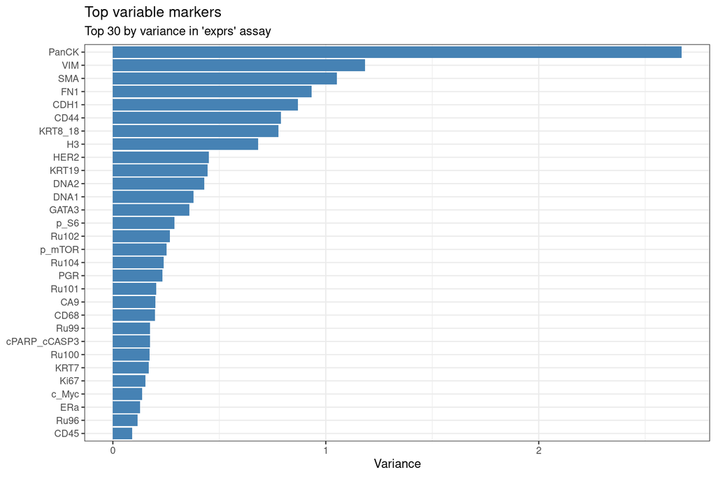

Figure 2: Top variable markers retained for dimensionality reduction.

```r
top_markers_tbl <- marker_metrics_keep |>
  dplyr::slice_head(n = top_n) |>
  dplyr::mutate(
    marker_name = factor(marker_name, levels = rev(marker_name))
  )

ggplot(top_markers_tbl, aes(x = marker_name, y = variance_expr)) +
  geom_col(fill = "steelblue") +
  coord_flip() +
  labs(
    title = "Top variable markers",
    subtitle = sprintf("Top %d by variance in '%s' assay", top_n, analysis_assay),
    x = NULL,
    y = "Variance"
  ) +
  theme_bw()
```

## 7 Save outputs

```r
params_tbl <- data.frame(
  parameter = c("analysis_assay", "min_pct_nonzero", "n_top_variable_markers",
                "n_cells_retained", "n_markers_retained"),
  value = c(
    analysis_assay,
    as.character(min_pct_nonzero),
    as.character(n_top_variable_markers),
    as.character(ncol(sce_preprocessed)),
    as.character(nrow(sce_preprocessed))
  )
)

write.csv(marker_metrics,
          file = file.path("..", "results", "preprocessing_summary", "marker_preprocessing_metrics.csv"),
          row.names = FALSE)

write.csv(params_tbl,
          file = file.path("..", "results", "preprocessing_summary", "preprocessing_parameters.csv"),
          row.names = FALSE)

saveRDS(sce_preprocessed, file = file.path("..", "results", "sce_preprocessed.rds"))

params_tbl
```

```
               parameter  value
1         analysis_assay  exprs
2        min_pct_nonzero      1
3 n_top_variable_markers     30
4       n_cells_retained 272975
5     n_markers_retained     42
```

```r
cat("Saved:\n")
```

```
Saved:
```

```r
cat("  results/preprocessing_summary/marker_preprocessing_metrics.csv\n")
```

```
  results/preprocessing_summary/marker_preprocessing_metrics.csv
```

```r
cat("  results/preprocessing_summary/preprocessing_parameters.csv\n")
```

```
  results/preprocessing_summary/preprocessing_parameters.csv
```

```r
cat("  results/sce_preprocessed.rds\n")
```

```
  results/sce_preprocessed.rds
```

**TipNext step**

Proceed to dimensionality reduction and clustering notebooks using `results/sce_preprocessed.rds` as input.